# Bayesian Phylogenetic Structure

Ben Weinstein

Tuesday, November 04, 2014

# Aim

Insights from comparing phylogenetic and trait community spacing has led to a renewed focus on whether interspecific competition shape species occurrence. Combining theories of niche conservatism and limiting similarity, species should co-occur more with closely related species up to a threshold of niche overlap, followed by a decrease in co-occurrence. I developed a hierarchical Bayesian approach to assess probability of co-occurrence as a function of distance to the closest related species in hummingbird assemblages from Northern South America. I tested a fully constrained, varying intercepting and varying slope and intercept model.

# Bayesian Analysis of co-occurrence and relatedness.

## General Model Formula

$Y_i \sim Bern(p_i)$

$logit(p_i) = \alpha + \beta *x + \gamma *x^2$

$\text{p is the probability of presence at a site}$ $\text{x= cophenetic distance to the most closely related species }$

# Model I - Constrained - Single Slope and Intercept

Species are constrained to have the same slope and intercept.

$Y_i \sim Bern(p_i)$

$logit(p_i) = \alpha + \beta *x + \gamma *x^2$

WinBugs code:

```
##  [1] setwd("C:/Users/Ben/Documents/Pred_Obs/Bayesian")
##  [2]
##  [3] sink("Single.jags")
##  [4]
##  [5] cat("model{
##  [6]     for(i in 1:length(y)){
##  [7]     y[i] ~ dbern(p[i])
##  [8]     logit(p[i]) <- alpha + beta * dist[i] + gamma * pow(dist[i],2)
##  [9]     }
## [10]
## [11]     alpha ~ dnorm(0,0.001)
## [12]     beta ~ dnorm(0,0.001)
## [13]     gamma ~ dnorm(0,0.001)
## [14]
## [15]     }",fill = TRUE)
## [16]
## [17] sink()
```

### Visualize posteriors

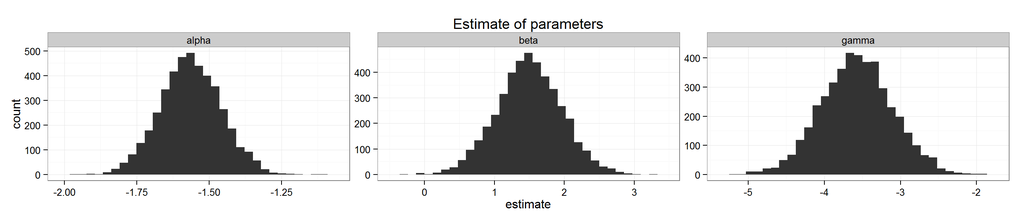

### Visualize chains

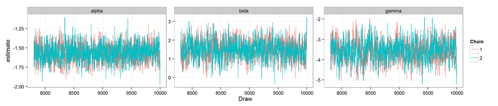

### Output table

```
## Source: local data frame [3 x 5]
##
##   parameter   mean   lower  upper     sd
## 1     alpha -1.564 -1.7703 -1.353 0.1055
## 2      beta  1.496  0.5689  2.406 0.4672
## 3     gamma -3.574 -4.5018 -2.629 0.4743
```

### Plot curves

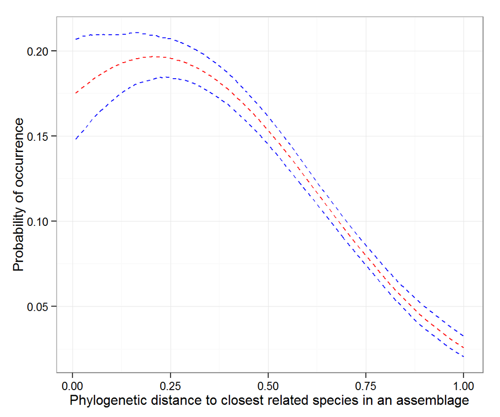

```r
#Load if needed

dpars<-dcast(parsSingle,...~parameter)

#sample 1000 values
samp<-dpars[sample(1:nrow(dpars),500),]

traj<-list()
for(x in 1:nrow(samp)){
  s<-samp[x,]
  p<-inv.logit(s$alpha + s$beta* dat$Phylo.Relatedness +s$gamma * dat$Phylo.Relatedness^2)
  traj[[x]]<-data.frame(x=dat$Phylo.Relatedness,y=p,Iteration=x)
}
    traj<-rbind_all(traj)

#summarise mean and interval
mtraj<-group_by(traj,x) %>% summarise(mean=mean(y),upper=quantile(y,0.975),lower=quantile(y,0.025))

ggplot(mtraj,aes(x=x,y=mean)) + geom_line(col="red",linetype="dashed") + geom_line(aes(y=upper),col="blue",linetype="dashed") + geom_line(aes(y=lower),col="blue",linetype="dashed")+ theme_bw() + labs(x="Phylogenetic distance to closest related species in an assemblage",y="Probability of occurrence")
```

# Model II - Unconstrained - Varying Intercept

Species have differing intercepts but constrained to have the same slope. This equates to a single mechanism shaping relatedness, but accounting for differences in occupancy between species.

$Y_i \sim Bern(p_i)$

$logit(p_i) = \alpha_{Species[i]} + \beta *x + \gamma *x^2$ $\alpha_{Species[i]} \sim N(intercept,sigmaIntercept)$

WinBugs code:

```
##  [1] setwd("C:/Users/Ben/Documents/Pred_Obs/Bayesian")
##  [2]
##  [3] sink("SingleSlope.jags")
##  [4]
##  [5] cat("model{
##  [6]     for(i in 1:length(y)){
##  [7]     y[i] ~ dbern(p[i])
##  [8]     logit(p[i]) <- alpha[Species[i]] + beta * dist[i] + gamma * pow(dist[i],2)
##  [9]     }
## [10]
## [11]     for (j in 1:s){
## [12]     alpha[j] ~ dnorm(intercept,tauIntercept)
## [13]     }
## [14]
## [15]     beta ~ dnorm(0,0.001)
## [16]     gamma ~ dnorm(0,0.001)
## [17]
## [18]     intercept ~ dnorm(0,0.001)
## [19]     tauIntercept ~ dgamma(0.001,0.001)
## [20]     sigmaIntercept<- pow(1/tauIntercept,.5)
## [21]
## [22]     }",fill = TRUE)
## [23]
## [24] sink()
```

Run jags.

### Visualize posteriors

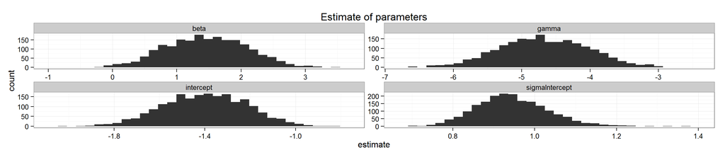

### Visualize chains

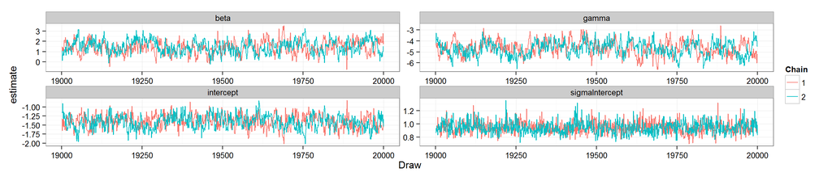

### Output table

[output not shown]

## Plot species models

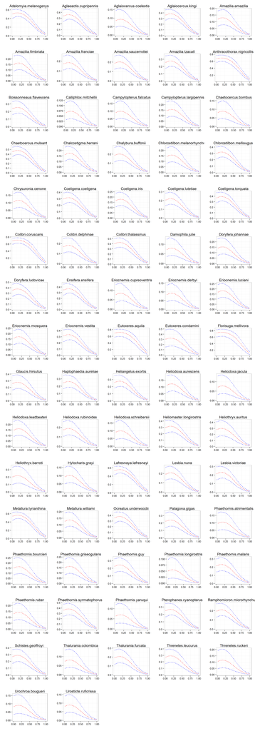

## Model III - Unconstrained - Varying Intercept and Slope

Species are unconstrained in both slopes and intercepts. Species each repond differently and having different occupancies, but are drawn from a hyperprior

$Y_i \sim Bern(p_i)$

$logit(p_i) = \alpha_{Species[i]} + \beta_{Species[i]} *x + \gamma_{Species[i]} *x^2$ $\alpha_{Species[i]} \sim N(intercept,sigmaIntercept)$ $\beta_{Species[i]} \sim N(slope,sigmaSlope)$ $\gamma_{Species[i]} \sim N(slope2,sigmaSlope2)$

WinBugs code:

```
##  [1] setwd("C:/Users/Ben/Documents/Pred_Obs/Bayesian")
##  [2]
##  [3] sink("BPhylo.jags")
##  [4]
##  [5] cat("model{
##  [6]   for(i in 1:length(y)){
##  [7]       y[i] ~ dbern(p[i])
##  [8]       logit(p[i]) <- alpha[Species[i]] + beta[Species[i]] * dist[i] + gamma[Species[i]] * pow(dist[i],2)
##  [9]     }
## [10]
## [11]     for (j in 1:s){
## [12]     beta[j] ~ dnorm(linear,tauSlope)
## [13]     alpha[j] ~ dnorm(intercept,tauIntercept)
## [14]     gamma[j] ~ dnorm(polynomial,tauSlope2)
## [15]     }
```

[output cut: 17 more lines]

Run jags

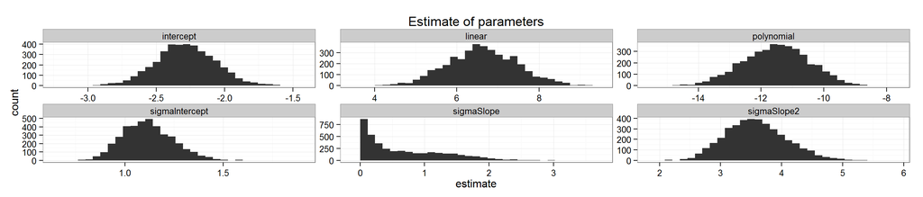

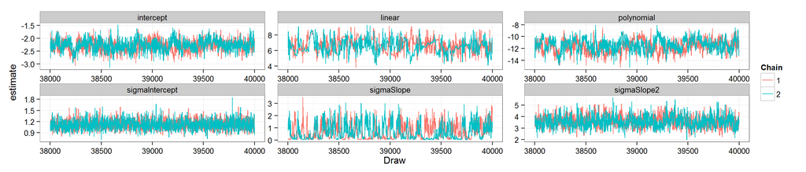

### Output table

```
## Source: local data frame [6 x 5]
##
##        parameter     mean     lower  upper     sd
## 1      intercept  -2.2852  -2.71059 -1.854 0.2177
## 2         linear   6.6275   5.02175  8.321 0.8403
## 3     polynomial -11.5226 -13.58951 -9.567 1.0507
## 4 sigmaIntercept   1.1175   0.89239  1.395 0.1301
## 5     sigmaSlope   0.6765   0.03231  2.073 0.6215
## 6    sigmaSlope2   3.5822   2.68437  4.639 0.5041
```

## View species posteriors

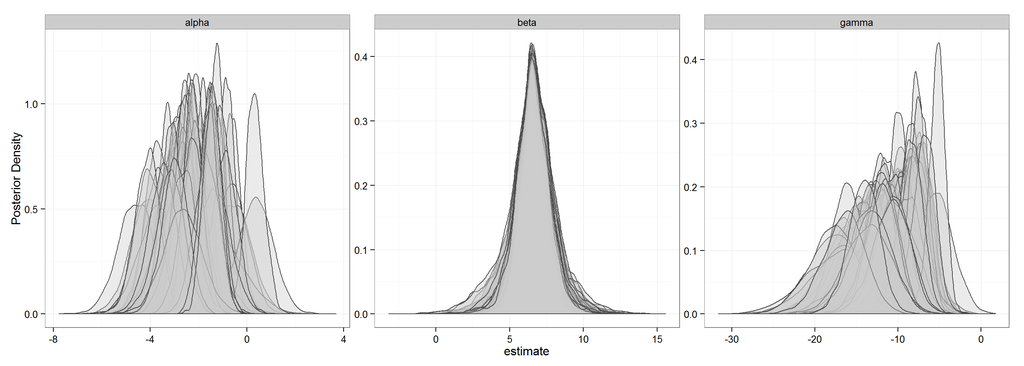

## View Species

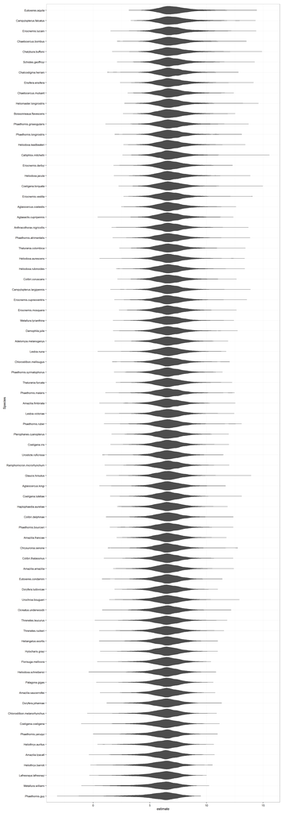

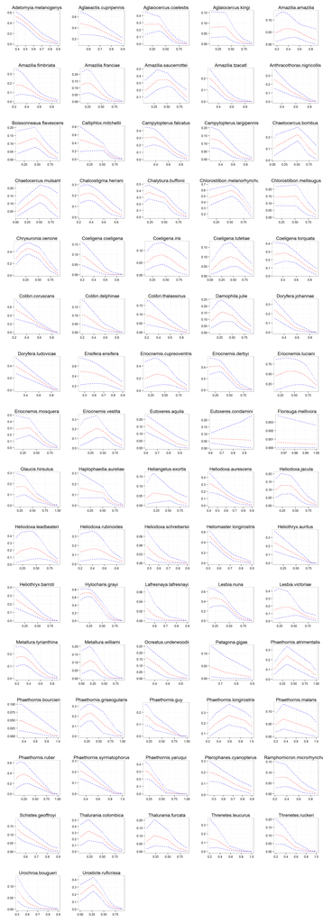

# Comparison of Model Estimates

Group by the parameters they are trying to predict

[figure not shown]

# Inference

These data support the non-linear relationship betwen phylogenetic relatedness and occurrence in hummingbirds. The decrease among closely related species could be evidence of limiting similarity due to niche overlap, which will be tested against null models of assemblage structure.